# LAB 43 (MD)

AnaGSanjuanM

2023-03-10

—————–LABORATORIO 43———————

—————–PRETTYHEATMAP———————-

—ACADÉMICO: DRA. CARLA CAROLINA PÉREZ HERNÁNDEZ—

———ALUMNA: ANA GRISEL SANJUAN MERIDA———-

Laboratorio: Mapa de calor térmico

Datos genicos tomados de Sahir Bhatnagar

Objetivo: Realizar un heatmap con datos geneticos

En este ejercicio vamos a:

1. Cargar matriz hipotética de datos y dataframes adicionales
2. Realizar varios heatmaps

El mapa de calor es una representación gráfica de datos que utiliza un sistema de codificación de colores para representar diferentes valores

Instalar paquetería: install.packages(“pheatmap”)

Abrir la librería

```r
library(pheatmap)
```

Importar datos

Como son tres archivos que se ocuparán, debo activar las tres rutas

file.choose

El primer archivo se convertirá en matriz

Objeto matricial llamado genes que será leída como matriz

Está en formato csv.

Está separado por comas sep=“,”

En el encabezado están los títulos header=T

En la primera columna están los nombres de los genes row.names=1

```r
genes <- as.matrix(
  read.csv("C:\\Users\\Lenovo\\Documents\\GitHub\\LAB-43\\L43 Input\\heatmap_data.csv",
           sep=",",
           header=T,
           row.names=1))
```

En el environment se ve el objeto generado genes

Los otros dos archivos serán dataframes

Objeto llamado annotation_row

Está en formato csv.

En el encabezado están los títulos header=T

En la primera columna están los nombres de los genes row.names=1

```r
annotation_row <- read.csv("C:\\Users\\Lenovo\\Documents\\GitHub\\LAB-43\\L43 Input\\annotation_row.csv", header=T,
                           row.names=1)
```

Objeto llamado annotation_col

Está en formato csv.

En el encabezado están los títulos header=T

En la primera columna están los nombres de los genes row.names=1

```r
annotation_col <- read.csv("C:\\Users\\Lenovo\\Documents\\GitHub\\LAB-43\\L43 Input\\annotation_col.csv", header=T,
           row.names=1)
```

Dibujando el heatmap

Comando pheatmap y la matriz genes

```r
pheatmap(genes)
```

[output not shown]

Cambiando el tamaño de la fuente (los cuadritos)

```r
pheatmap(genes, frontsize=6)
```

[output not shown]

Quitando uno de los dendrogramas

Se quitará el dendrograma de las columnas, por lo que los renglones si interesan (true)

Como las columnas de pacientes (eje de las X) no estarán, ponemos False

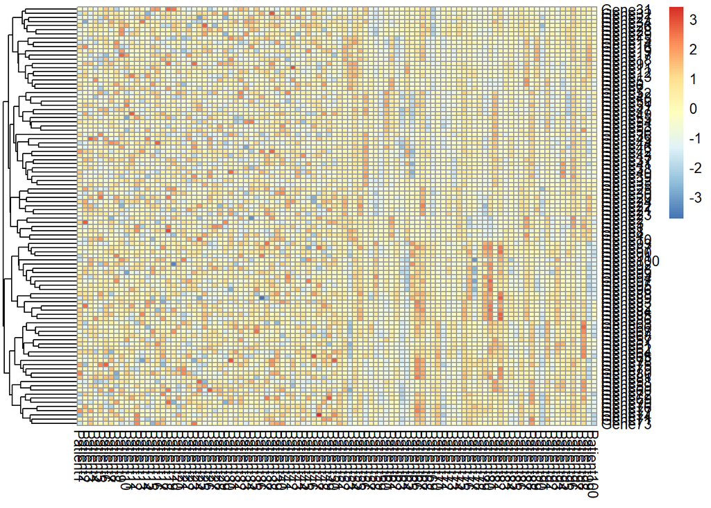

```r
pheatmap(genes, frontsize=6, cluster_rows = T, cluster_cols = F)
```

Se quitará el dendrograma de los renglones, por lo que las columnas si interesan (true)

Como los renglones de genes (eje de las Y) no estarán, ponemos False

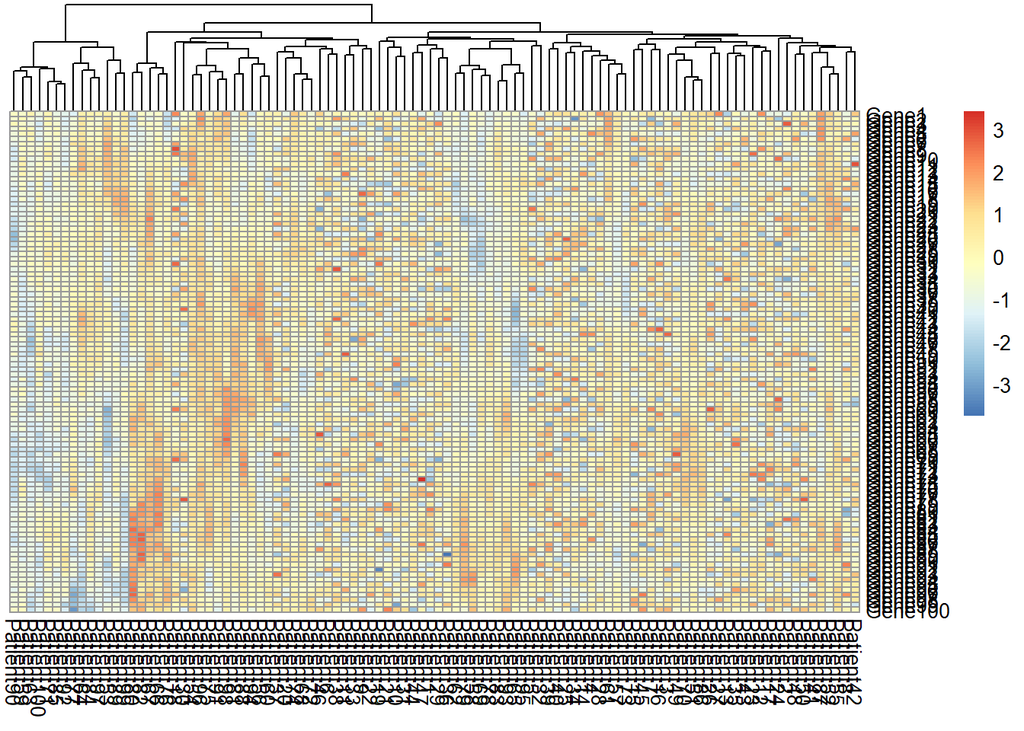

```r
pheatmap(genes, frontsize=6, cluster_rows = F, cluster_cols = T)
```

Para que se muestren nuevamente los dendrogramas en ambos ejes

```r
pheatmap(genes, frontsize=6, cluster_rows = T, cluster_cols = T)
```

[output not shown]

Identificar si hay patrones sibyacentes a las anotaciones de columnas y renglones

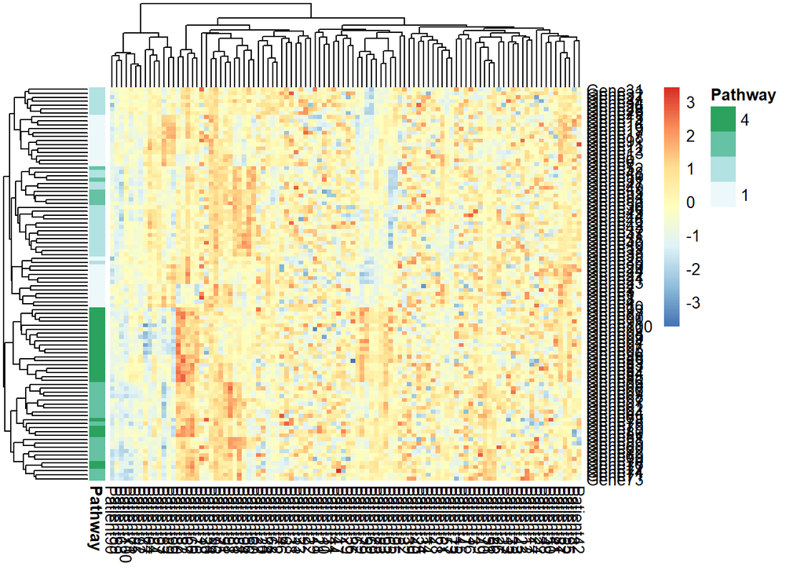

```r
pheatmap(genes, frontsize=6, cluster_rows = T, cluster_cols = T, annotation_row = annotation_row)
```

Para añadir anotaciones en las columnas

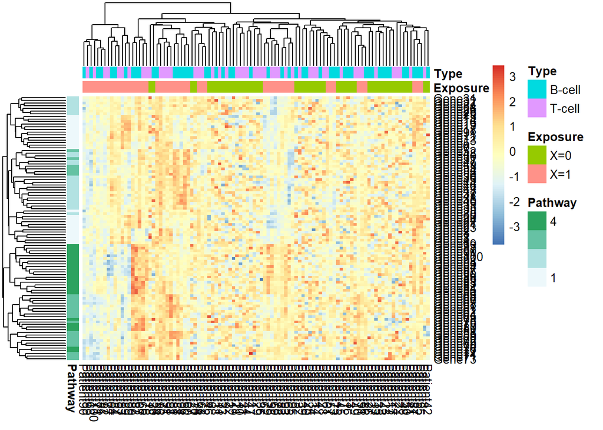

```r
pheatmap(genes, frontsize=6, cluster_rows = T, cluster_cols = T, annotation_row = annotation_row, annotation_col = annotation_col)
```

Generar gráfico de manera completa

Se quita dendrograma de renglones

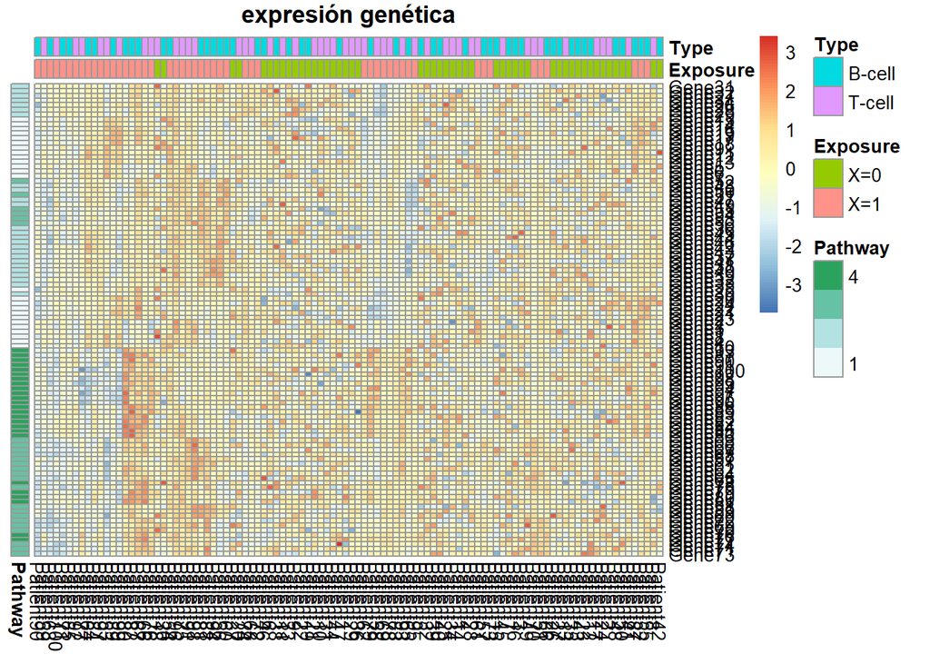

```r
pheatmap(genes, frontsize=6, cluster_rows = T, cluster_cols = T, annotation_row = annotation_row, annotation_col = annotation_col, treeheight_row = 0, treeheight_col = 0, main = "expresión genética")
```

Tomando una pequeña muestra de la base general para crear un subset

El subconjunto de datos proviene de la base matricial llamada genes

Extraerá ciertos datos de un vector (del gen 1 al gen 5)

```r
sub <- genes [c(1:5, 55:60), c(1:5, 20:35, 55:60)]
```

Generar mapa de calor del subconjunto llamado sub

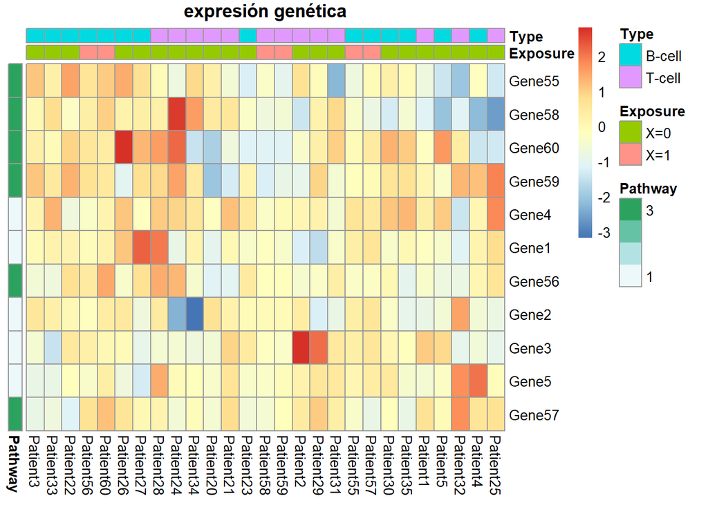

```r
pheatmap(sub, frontsize=6, cluster_rows = T, cluster_cols = T, annotation_row = annotation_row, annotation_col = annotation_col, treeheight_row = 0, treeheight_col = 0, main = "expresión genética")
```

Desplegar valores del gráfico recién obtenido

Del mapa de calor del subconjunto llamado sub el tamaño será de 8

Las anotaciones de la leyenda será falsa

Desplegar los números (True)

El tamaño de los números será de 6

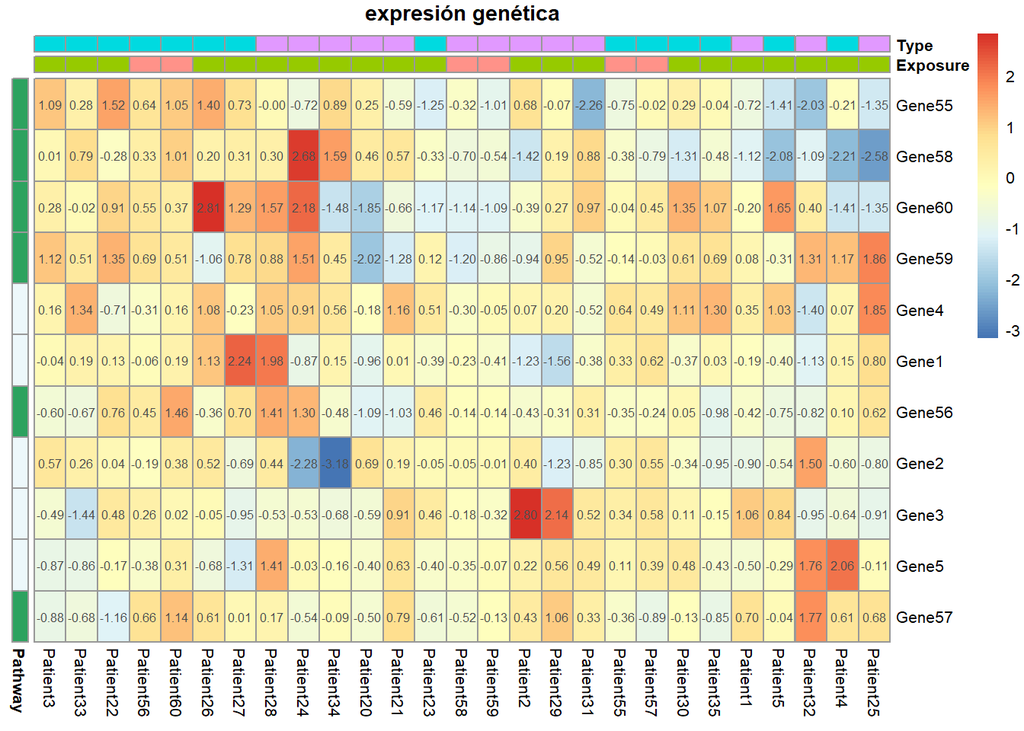

```r
pheatmap(sub, frontsize=6, cluster_rows = T, cluster_cols = T, annotation_row = annotation_row, annotation_col = annotation_col, treeheight_row = 0, treeheight_col = 0, main = "expresión genética", fontsize = 8, annotation_legend = FALSE, display_numbers = TRUE, fontsize_number = 6)
```

Para añadir elemento estético adicional

Cargamos paquetería para cambiar color:

install.packages(“viridis”)

install.packages(“viridisLite”)

Abrimos la librería

```r
library(viridis)
```

Hay cuatro paletas de colores: magma, plasma, cividis e inferno

Volviendo a cargar pheatmap

```r
library(pheatmap)
```

Uso de paletas de colores para una mejor estética

Se usará paleta viridis y la opción plasma

Y seis facetas diferentes

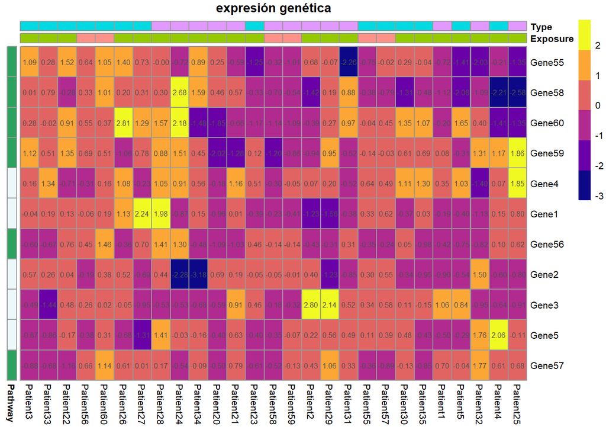

```r
pheatmap(sub, frontsize=6, cluster_rows = T, cluster_cols = T, annotation_row = annotation_row,
         annotation_col = annotation_col, treeheight_row = 0, treeheight_col = 0,
         main = "expresión genética", fontsize = 8, annotation_legend = FALSE, display_numbers = TRUE,
         fontsize_number = 6, col=viridis_pal(option="plasma") (6))
```

Para usar otro tono de paleta de colores: magma

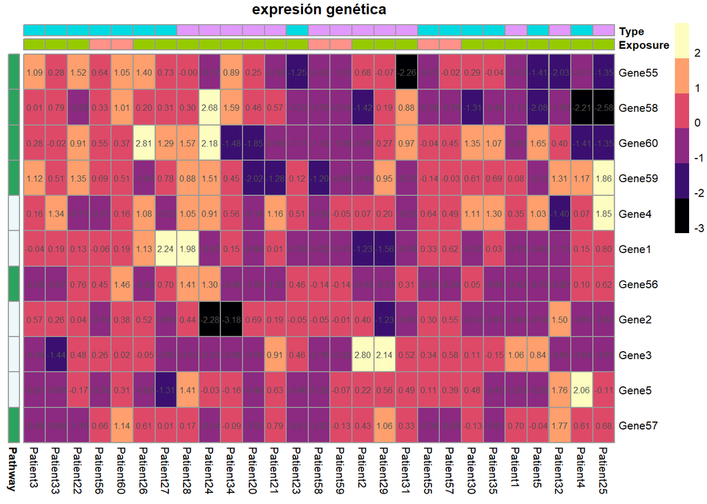

```r
pheatmap(sub, frontsize=6, cluster_rows = T, cluster_cols = T, annotation_row = annotation_row,
         annotation_col = annotation_col, treeheight_row = 0, treeheight_col = 0,
         main = "expresión genética", fontsize = 8, annotation_legend = FALSE, display_numbers = TRUE,
         fontsize_number = 6, col=viridis_pal(option="magma") (6))
```

Para usar otro tono de paleta de colores: viridis

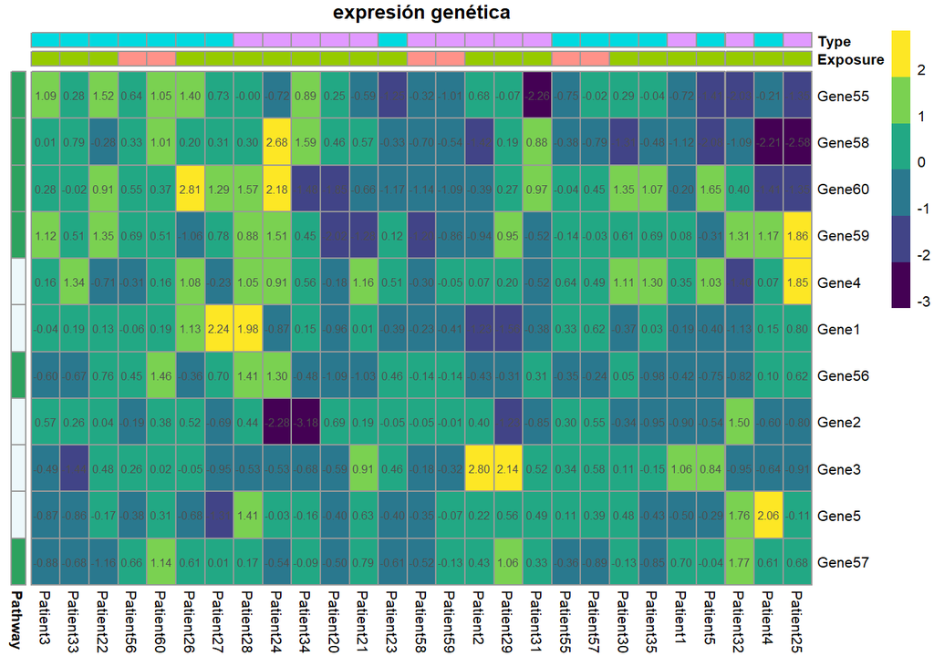

```r
pheatmap(sub, frontsize=6, cluster_rows = T, cluster_cols = T, annotation_row = annotation_row,
         annotation_col = annotation_col, treeheight_row = 0, treeheight_col = 0,
         main = "expresión genética", fontsize = 8, annotation_legend = FALSE, display_numbers = TRUE,
         fontsize_number = 6, col=viridis_pal(option="viridis") (6))
```

Algunos elementos adicionales

Identificar la distribución de las distancias

```r
dist(sub)
```

```
##           Gene1    Gene2    Gene3    Gene4    Gene5   Gene55   Gene56   Gene57
## Gene2  6.506125
## Gene3  7.823569 7.021725
## Gene4  5.253565 7.649124 6.516104
## Gene5  6.411847 5.977640 5.967513 6.184570
## Gene55 5.703940 6.969997 7.096321 6.837653 7.534618
## Gene56 4.544832 6.723925 6.542745 5.805165 5.150859 6.028094
## Gene57 6.124657 6.069362 5.550487 6.004035 3.881691 7.122986 5.209746
## Gene58 7.417422 8.796956 8.462521 7.874145 8.030439 6.777444 6.292359 7.669524
## Gene59 6.189649 8.293720 7.977707 6.115718 5.821355 7.317126 4.835770 6.104449
## Gene60 6.623226 8.133474 7.665999 6.837342 7.659167 7.569942 6.373711 7.296198
##          Gene58   Gene59
## Gene2
## Gene3
## Gene4
## Gene5
## Gene55
## Gene56
## Gene57
## Gene58
## Gene59 8.312043
## Gene60 7.813793 6.992657
```

Visualzar la correlación existente entre los genes

Identificar matriz transpuesta

Crear objeto llamado trans

Dicho dataframe será igual a la matriz trasnpuesta de la sub base de datos

```r
trans <- t(sub)
```

Mapa de calor de la correlación de los genes con la matriz transpuesta

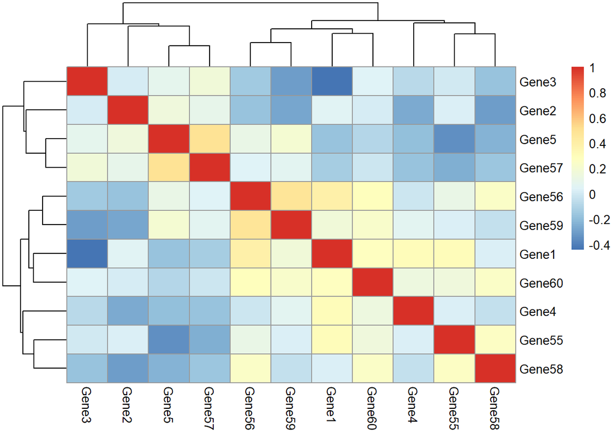

```r
pheatmap(cor(trans))
```

————————FIN DE LABORATORIO 43————————-